# Project 1

# Step 0: check and install needed packages. Load the libraries and functions.

```r
packages.used=c("rvest", "tibble", "qdap",
                "sentimentr", "gplots", "dplyr",
                "tm", "syuzhet", "factoextra",
                "beeswarm", "scales", "RColorBrewer",
                "RANN", "tidytext", "topicmodels","wordcloud")
# check packages that need to be installed.
packages.needed=setdiff(packages.used,
                        intersect(installed.packages()[,1],
                                  packages.used))
# install additional packages
if(length(packages.needed)>0){
  install.packages(packages.needed, dependencies = TRUE)
}
# load packages
library("rvest")
library("tibble")
library("qdap")
library("sentimentr")
library("gplots")
library("dplyr")
library("tm")
library("syuzhet")
library("factoextra")
library("beeswarm")
library("scales")
library("RColorBrewer")
library("RANN")
library("tidytext")
library("topicmodels")
library("wordcloud")
source("../lib/plotstacked.R")
source("../lib/speechFuncs.R")
```

# Step 1: Data harvest: scrap speech URLs from [American Presidency Project](http://www.presidency.ucsb.edu/).

```r
### Inauguaral speeches
main.page <- read_html(x = "http://www.presidency.ucsb.edu/inaugurals.php")
# Get link URLs
# f.speechlinks is a function for extracting links from the list of speeches.
inaug=f.speechlinks(main.page)
#head(inaug)
as.Date(inaug[,1], format="%B %e, %Y")
```

```
 [1] "1789-04-30" "1793-03-04" "1797-03-04" "1801-03-04" "1805-03-04" "1809-03-04" "1813-03-04" "1817-03-04"
 [9] "1821-03-04" "1825-03-04" "1829-03-04" "1833-03-04" "1837-03-04" "1841-03-04" "1845-03-04" "1849-03-05"
[17] "1853-03-04" "1857-03-04" "1861-03-04" "1865-03-04" "1869-03-04" "1873-03-04" "1877-03-05" "1881-03-04"
[25] "1885-03-04" "1889-03-04" "1893-03-04" "1897-03-04" "1901-03-04" "1905-03-04" "1909-03-04" "1913-03-04"
[33] "1917-03-04" "1921-03-04" "1925-03-04" "1929-03-04" "1933-03-04" "1937-01-20" "1941-01-20" "1945-01-20"
[41] "1949-01-20" "1953-01-20" "1957-01-21" "1961-01-20" "1965-01-20" "1969-01-20" "1973-01-20" "1977-01-20"
[49] "1981-01-20" "1985-01-21" "1989-01-20" "1993-01-20" "1997-01-20" "2001-01-20" "2005-01-20" "2009-01-20"
[57] "2013-01-21" "2017-01-20" NA
```

```r
inaug=inaug[-nrow(inaug),] # remove the last line, irrelevant due to error.
```

# Step 2: Using speech metadata posted on [American Presidency Project](http://www.presidency.ucsb.edu/), we prepared CSV data sets for the speeches we will scrap.

```r
inaug.list=read.csv("../data/inauglist.csv", stringsAsFactors = FALSE)
```

We assemble all scrapped speeches into one list. Note here that we don’t have the full text yet, only the links to full text transcripts.

# Step 3: scrap the texts of speeches from the speech URLs.

```r
speech.list=inaug.list
speech.list$type=rep("inaug", nrow(inaug.list))
speech.url=inaug
speech.list=cbind(speech.list, speech.url)
```

Based on the list of speeches, we scrap the main text part of the transcript’s html page. For simple html pages of this kind, [Selectorgadget](http://selectorgadget.com/) is very convenient for identifying the html node that `rvest` can use to scrap its content. For reproducibility, we also save our scrapped speeches into our local folder as individual speech files.

```r
# Loop over each row in speech.list
speech.list$fulltext=NA
for(i in seq(nrow(speech.list))) {
  text <- read_html(speech.list$urls[i]) %>% # load the page
    html_nodes(".displaytext") %>% # isloate the text
    html_text() # get the text
  speech.list$fulltext[i]=text
  # Create the file name
  filename <- paste0("../data/fulltext/",
                     speech.list$type[i],
                     speech.list$File[i], "-",
                     speech.list$Term[i], ".txt")
  sink(file = filename) %>% # open file to write
  cat(text)  # write the file
  sink() # close the file
}
```

```r
speech.corpus <- Corpus(VectorSource(speech.list$fulltext))
speech.corpus <- tm_map(speech.corpus, stripWhitespace)
speech.corpus <- tm_map(speech.corpus, content_transformer(tolower))
speech.corpus <- tm_map(speech.corpus, removeWords, stopwords("english"))
speech.corpus <- tm_map(speech.corpus, removeWords, character(0))
speech.corpus <- tm_map(speech.corpus, removePunctuation)
tdm.all <- TermDocumentMatrix(speech.corpus)
tdm.tidy <- tidy(tdm.all)
tdm.overall <- summarise(group_by(tdm.tidy, term),sum(count))
```

Now we have all the texts we need, then we can do the text mining,

First let’s try the Wordcloud.

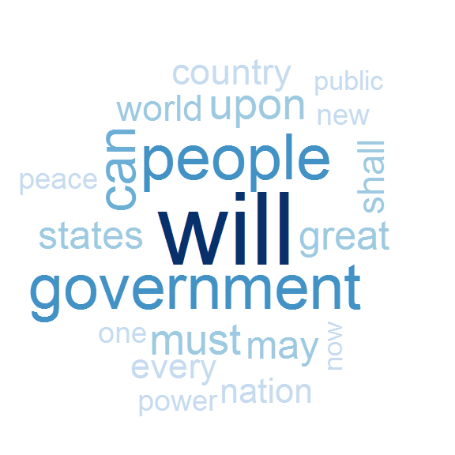

```r
wordcloud(tdm.overall$term, tdm.overall$`sum(count)`,
          scale=c(8,0.3),
          max.words=20,
          min.freq=10,
          random.order=FALSE,
          rot.per=0.3,
          use.r.layout=T,
          random.color=FALSE,
          colors=brewer.pal(9,"Blues"))
```

That is the general wordcloud for all inaugration speeches.

Let’s try the word frequency. First count the words usage.

```r
speech_tidy <- tidy(speech.corpus)
speech_tidy$author <- inaug.list$File
speech_token <- speech_tidy %>%
    unnest_tokens(word, text) %>%
  anti_join(stop_words, by = "word")
speech_token %>%
  count(word, sort = TRUE)
```

| word | n |
| --- | --- |
| people | 567 |
| government | 562 |
| world | 306 |
| country | 304 |
| nation | 292 |
| peace | 249 |
| power | 236 |
| public | 225 |
| nations | 221 |
| time | 215 |

[output cut: 990 more lines]

Then calculate the frequency.

```r
freq_inaug <- speech_token %>%
    group_by(author) %>%
    count(word, sort = TRUE)%>%
    left_join(speech_token %>%
                  group_by(author) %>%
                  summarise(total = n())) %>%
    mutate(freq = n/total)
freq_inaug
```

| author | word | n | total | freq |
| --- | --- | --- | --- | --- |
| WilliamHenryHarrison | power | 47 | 2923 | 0.016079371 |
| JamesKPolk | government | 44 | 1839 | 0.023926047 |
| WilliamHenryHarrison | people | 38 | 2923 | 0.013000342 |
| WilliamMcKinley | people | 37 | 2344 | 0.015784983 |
| WilliamHenryHarrison | constitution | 36 | 2923 | 0.012316114 |
| WilliamHenryHarrison | government | 36 | 2923 | 0.012316114 |
| WilliamMcKinley | government | 36 | 2344 | 0.015358362 |
| JamesKPolk | union | 32 | 1839 | 0.017400761 |
| JamesMonroe | government | 32 | 2754 | 0.011619463 |
| RichardNixon | peace | 32 | 1312 | 0.024390244 |

[output cut: 990 more lines]

That is how individual president uses words.

Then try again the wordcloud for some presidents.

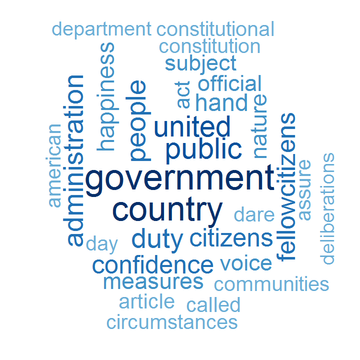

```r
wordcloud(freq_inaug$word[freq_inaug$author == "GeorgeWashington"], freq_inaug$n,
          scale=c(4.5,0.3),
          max.words=30,
          min.freq=10,
          random.order=FALSE,
          rot.per=0.3,
          use.r.layout=T,
          random.color=FALSE,
          colors=brewer.pal(9,"Blues"))
```

```r
wordcloud(freq_inaug$word[freq_inaug$author == "AbrahamLincoln"], freq_inaug$n,
          scale=c(4.5,0.3),
          max.words=30,
          min.freq=10,
          random.order=FALSE,
          rot.per=0.3,
          use.r.layout=T,
          random.color=FALSE,
          colors=brewer.pal(9,"Blues"))
```

[output not shown]

```r
wordcloud(freq_inaug$word[freq_inaug$author == "JohnFKennedy"], freq_inaug$n,
          scale=c(4.5,0.3),
          max.words=30,
          min.freq=10,
          random.order=FALSE,
          rot.per=0.3,
          use.r.layout=T,
          random.color=FALSE,
          colors=brewer.pal(9,"Blues"))
```

[output not shown]

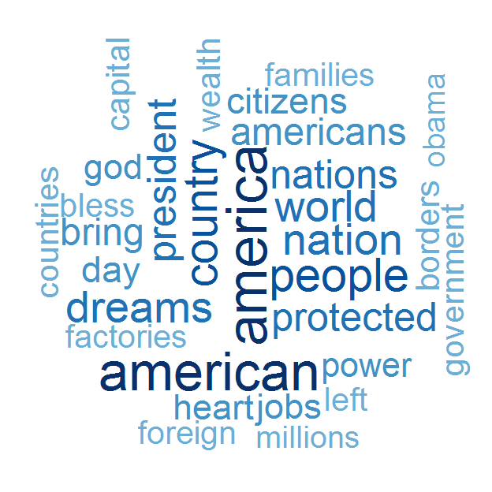

```r
wordcloud(freq_inaug$word[freq_inaug$author == "DonaldJTrump"], freq_inaug$n,
          scale=c(4.5,0.3),
          max.words=30,
          min.freq=10,
          random.order=FALSE,
          rot.per=0.3,
          use.r.layout=T,
          random.color=FALSE,
          colors=brewer.pal(9,"Blues"))
```

And I think from the wordclouds above, we can see that there are some differences in word using between each presidents, so I study the variation of the use of each word. We could extract the year from each document’s name, and compute the total number of words within each year.

```r
library(methods)
library(tidyr)
data("data_corpus_inaugural", package = "quanteda")
inaug_dfm <- quanteda::dfm(data_corpus_inaugural)

inaug_td <- tidy(inaug_dfm)

year_term_counts <- inaug_td %>%
  extract(document, "year", "(\\d+)", convert = TRUE) %>%
  complete(year, term, fill = list(count = 0)) %>%
  group_by(year) %>%
  mutate(year_total = sum(count))

year_term_counts %>%
  filter(term %in% c("will",  "can" , "public", "union", "america", "time","power","peace", "people")) %>%
  ggplot(aes(year, count / year_total)) +
  geom_point() +
  geom_smooth() +
  facet_wrap(~ term, scales = "free_y") +
  scale_y_continuous(labels = scales::percent_format()) +
  ylab("% frequency of word in inaugural address")
```

[output not shown]